# Image Classification (CIFAR 100)

```python
!pip install --quiet keras-tuner tqdm wandb pytz tensorflow-addons glob2
```

# Objectives & goals for CA1

1. Perform image classification on the CIFAR-100 dataset and obtain a good competitive accuracy score (low avoidable bias), simultaneously searching for a model that does not overfit.
2. Try out different training methodology and experiment with SOTA model architectures, training procedures and data augmentation without hurting the performance of model

# Prediction task

> - **Can we develop a deep learning model to classify images in the CIFAR-100 dataset, particularly using a CNN architecture**
> - **This is a multi-class classification task**

**I will skip data understanding and exploration as it has been covered earlier**

### General Imports

```python
import numpy as np
import pandas as pd
from matplotlib import pyplot as plt
from matplotlib.ticker import FormatStrFormatter
import matplotlib
from tqdm import tqdm
import seaborn as sns
import os, time, math, datetime, warnings, pytz, glob
from IPython.display import display
from functools import reduce, wraps
from sklearn.metrics import classification_report,accuracy_score, confusion_matrix
warnings.filterwarnings('ignore')

os.environ['TF_CPP_MIN_LOG_LEVEL'] = '2'  # Ignore warnings

%matplotlib inline
```

```python
import absl.logging
absl.logging.set_verbosity(absl.logging.ERROR)
# ignore warning
import logging
logging.getLogger('tensorflow').disabled = True
```

```python
import sys
if 'google.colab'  not in sys.modules:
    os.environ['CUDA_VISIBLE_DEVICES'] = '-1'
```

### Tensorflow imports

```python
import tensorflow as tf
# Data source
from tensorflow.keras.datasets import cifar100

from tensorflow.keras.utils import Sequence, to_categorical

# Modelling
from tensorflow.keras import Sequential
from tensorflow.keras.models import Model, load_model
from tensorflow.keras.layers import (Dense, Input, InputLayer, Normalization, Flatten,BatchNormalization,
    Dropout,Conv2D, GlobalAveragePooling2D, MaxPooling2D, ReLU, Layer,Activation, Multiply, AveragePooling2D,
    Add, RandomRotation,Resizing, Rescaling, Reshape, Concatenate, concatenate, Lambda)

from tensorflow.keras import layers as L
from tensorflow.keras import backend as K

from tensorflow.keras.utils import to_categorical, plot_model
from tensorflow.keras.callbacks import EarlyStopping, ModelCheckpoint, LearningRateScheduler, ReduceLROnPlateau, TerminateOnNaN, TensorBoard, CSVLogger, Callback
from tensorflow.keras.backend import clear_session
from tensorflow.keras.optimizers import RMSprop, SGD, Adam, Adagrad, Adamax


from tensorflow.keras.optimizers.schedules import *
from tensorflow.keras.metrics import FalseNegatives, categorical_crossentropy, sparse_categorical_crossentropy
from tensorflow.keras.regularizers import l2
from tensorflow.keras.losses import CategoricalCrossentropy
from tensorflow.keras.preprocessing.image import ImageDataGenerator
from tensorflow.image import random_flip_left_right, resize_with_crop_or_pad, random_crop
print('TensorFlow Version:', tf.__version__)

# TFA
from tensorflow_addons.optimizers import SWA


from kerastuner.tuners import Hyperband
from kerastuner import HyperModel
# from keras_adabound import AdaBound
```

```
TensorFlow Version: 2.10.0
```

```python
seed = 42
tf.random.set_seed(seed)
np.random.seed(seed)
# random seed for reproducibility
```

### Weights & Biases

- A MLOps platform with a novelty feature of experiment tracking to see machine learning model's performances of different versionings.
- Build better models faster with experiment tracking, dataset versioning, and model management

```python
import wandb
from wandb.keras import WandbCallback
```

```python
wandb.login()
# paste this pls e6ba4b45952ca612073be61bfda87ceca39072c5
```

```
Failed to detect the name of this notebook, you can set it manually with the WANDB_NOTEBOOK_NAME environment variable to enable code saving.
wandb: Currently logged in as: lhurr. Use `wandb login --relogin` to force relogin
```

```
True
```

### Check GPU

```python
print("Num GPUs Available: ", len(tf.config.list_physical_devices('GPU')))
print(tf.__version__)
print(tf.config.list_physical_devices('GPU'))
```

```
Num GPUs Available:  0
2.10.0
[]
```

### Reading dataset

1. We load the data using `load_data` and it returns 2 tuples for us
2. For the purpose of training and evaluating the model, we need to have our data in the form of 3 sets: `train`, `validation` and `test`. Ideally, the training data is used to train the model, validation data is used to perform tuning of models, and the test data will act as a final independant evaluation of the performance of the final model and its ability to generalize well.(low variance)
3. Furthermore, the model's performance can also be evaluated on the validation data on each epoch of training.
4. Hence, we will perform a 20% split on the train set (.8) to allocate 10000 images for the validation set (.2).
5. Since CIFAR100 dataset is not extremely large (not millions of records), i felt that a 20% split would be relevant. furthermore, we are also making decisions based on validation set. Hence, we must try to avoid overfitting the validation set.
- X_train: 40000
- X_val: 10000
- X_test: 10000

```python
(X_train_orig, y_train_orig), (X_test, y_test) = cifar100.load_data()
```

```python
IMG_SIZE = (32,32,3)
# third axis is the RGB channel
```

```python
X_train, y_train, X_val, y_val = X_train_orig[:40000], y_train_orig[:40000], X_train_orig[40000:], y_train_orig[40000:]
```

```python
NUM_CLASSES = 100
LABELS = {
0: 'apple',1: 'aquarium_fish',2: 'baby',3: 'bear',4: 'beaver',5: 'bed',6: 'bee',7: 'beetle',8: 'bicycle',9: 'bottle',10: 'bowl',
11: 'boy',12: 'bridge',13: 'bus',14: 'butterfly',15: 'camel',16: 'can',17: 'castle',18: 'caterpillar',19: 'cattle',20: 'chair',
21: 'chimpanzee',22: 'clock',23: 'cloud',24: 'cockroach',25: 'couch',26: 'cra',27: 'crocodile',28: 'cup',29: 'dinosaur',30: 'dolphin',31: 'elephant',
32: 'flatfish',33: 'forest',34: 'fox',35: 'girl',36: 'hamster',37: 'house',38: 'kangaroo',39: 'keyboard',40: 'lamp',41: 'lawn_mower',42: 'leopard',
43: 'lion',44: 'lizard',45: 'lobster',46: 'man',47: 'maple_tree',48: 'motorcycle',49: 'mountain',50: 'mouse',51: 'mushroom',52: 'oak_tree',53: 'orange',
54: 'orchid',55: 'otter',56: 'palm_tree',57: 'pear',58: 'pickup_truck',59: 'pine_tree',60: 'plain',61: 'plate',
62: 'poppy',63: 'porcupine',64: 'possum',65: 'rabbit',66: 'raccoon',67: 'ray',68: 'road',69: 'rocket',70: 'rose',71: 'sea',
72: 'seal',73: 'shark',74: 'shrew',75: 'skunk',76: 'skyscraper',77: 'snail',78: 'snake',79: 'spider',80: 'squirrel',81: 'streetcar',
82: 'sunflower',83: 'sweet_pepper',84: 'table',85: 'tank',86: 'telephone',87: 'television',88: 'tiger',89: 'tractor',90: 'train',
91: 'trout',92: 'tulip',93: 'turtle',94: 'wardrobe',95: 'whale',96: 'willow_tree',97: 'wolf',98: 'woman',99: 'worm'
}
```

# Preprocessing

- Before we feed data into models, we need to perform preprocessing.

  > **Pixel rescaling**
- Initially, the pixel values for each image in dataset are between 0 and 255.
- We need to rescale the pixel values to the range of 0 and 1. This is to handle the strong influence very large or small pixel values may pose. For example, if we do not scale, the network learns weights from features that are from different scales, and the large feature may 'drown' out the small features. Not rescaling the pixels can introduce the problem of exploding gradients, due to the high range of pixels.
- We will divide the pixel values by the maximum value of 255.
- This was a crucial step as it would improve optimization (faster) and especially critical for optimizers such as SGD, where it converges better and faster when pixel scales are similar. **One hot encoding for target labels**
- We will also one hot encode the target variable y from the label encoded format

```python
def preprocess(X,y):
    return X/255. , to_categorical(y, num_classes=NUM_CLASSES)
```

```python
X_train, y_train = preprocess(X_train, y_train)
X_test, y_test = preprocess(X_test, y_test)
X_val , y_val = preprocess(X_val, y_val)
```

# Modelling

### Evaluation metrics & optimization techniques

- We need to select our metrics/loss (to be optimized) along with our optimization techniques to sepcify under the `.compile()` method later.
- Optimization algorithms aims to minimize cost function, which is difference between the predicted data and the actual values

> **Metrics: Categorical accuracy**
> 1. Since this is a multi-class classification task, and given the fact we have one-hot encoded our `y` labels, `categorical_accuracy` will be used to evaluate the model's performance. However, if we choose to specify `accuracy`, it will not matter as Keras uses `categorical_accuracy` internally for multi-class classification. [Src](https://github.com/keras-team/keras/blob/master/keras/engine/training.py).

> **Optimizer: SGD with Nesterov Momentum vs Adaptive methods (like adam)**
> - Prior to modelling, we have to carefully select the optimization algorithm, particularly we want a optimizer that can enable the model to generalize well, with low variance, while simultaneously having low avoidable bias. I have shortlisted 2 optimization methods particular SGD or Adam (adaptive method)
> - After research, it was found that [adaptive optimization methods such as Adam have been proven to discover solutions that generalize poorly compared to Stochastic gradient descent](https://arxiv.org/pdf/1712.07628.pdf) [4], these methods tend to perform well on early stages but SGD then outperforms further into training. [It was also shown that the lack of generalization in performance of adaptive methods come from the non-uniform scaling of the gradient](https://arxiv.org/pdf/1705.08292.pdf) [5]. From another study of gradient noise, it was discovered that SGD is more locally unstable than Adam at sharp minimas, and can better [escape from them and converge to minima at the flat or asymmetric basins/valleys, which often have better generalization performance over sharp minimas. Hence, this highlights how SGD is able to generalize better as compared to adam](https://proceedings.neurips.cc/paper/2020/file/f3f27a324736617f20abbf2ffd806f6d-Paper.pdf) [7]. It was further noted that although adaptive methods yielded better training performance, it was not able to generalize as well as SGD, as shown in poor performance in benchmark dev and test set. [5]
> - Despite attempts to improve the generalization performance of Adam, such as introducing [ND ADAM](https://arxiv.org/abs/1709.04546) [6], which preserves gradient direction. However this improvement sacrifises the rapid initial speed of adam. Hence, there is still a gap between SGD and adaptive methods when it comes of generalization ability when it comes to image classification, with SGD being more reliable. However, one thing to note is that Adam has faster convergeance over SGD over lesser epochs. However, since we want our model to be robust, I choose to go with SGD with nesterov momentum **first**, and decide if we need to change it. **We will proceed with SGD first**

> **Activation Functions:**
> - Most of the time, we will be using a rectified linear unit activation function, so as to capture non linearities in the feature map.
> - I did not want to have many sigmoid activation function, as extreme values snap to 1 or -1, this would be challenging for the learning algorithm to continue and update the weights to improve the model.
> - RELU on the other hand, is more robust and is able to handle the problem of vanishing gradients, where the gradient diminishes as it is propagated through the network
> - Softmax: We will use softmax function usually for the last layer for the model to indicate to us the probability of the output class of being true. Softmax will also be used since this is a multi class classification problem

**References:**

- [4] https://arxiv.org/pdf/1712.07628.pdf
- [5] https://arxiv.org/pdf/1705.08292.pdf
- [6] https://arxiv.org/abs/1709.04546
- [7] https://proceedings.neurips.cc/paper/2020/file/f3f27a324736617f20abbf2ffd806f6d-Paper.pdf

**Optimization Hyperparameters**

> **Initial Learning rate**
> - The initial learning rate will be set to 0.1, this is consistent with the implementation details of some state of the art CNNs we will be using later on such as [WideResnet paper](https://arxiv.org/pdf/1605.07146.pdf). I decided to follow their recommendation on the optimization hyperparameters. "In all our experiments.... The initial learning rate is set to 0.1" [8]. I personally did not want to select too high of a learning rate, out of fear that the algorithm may diverge away from the optimal solution. A very small learning rate however may lead to slow convergence.

> **Momentum**
> - Momentum helps to speed up gradient descent and minimize oscillations, reducing fluctuations while approaching the optimal solution, which improves efficiency and speed of convergence. More specifically, momentum helps parameter vector to build up velocity in any direction with gradient descent.
> - We will be using a series of models such as pyramid net later on, and it was found that momentum of 0.9 worked well in the [Deep pyramidal networks implementation](https://arxiv.org/pdf/1610.02915.pdf) [9]. Furthermore, this value is quite popular among State of the art CNN architectures such as [Densely connected CNN](https://arxiv.org/pdf/1608.06993.pdf) [10] and WideResNets [8] and even Residual networks [13]. I decided to follow this value.

[figure not shown]

> Source: https://iopscience.iop.org/article/10.1088/1742-6596/1229/1/012046/pdf
> 1. [8] https://arxiv.org/pdf/1605.07146.pdf
> 2. [9] https://arxiv.org/pdf/1610.02915.pdf
> 3. [10] https://arxiv.org/pdf/1608.06993.pdf
> 4. [13] https://arxiv.org/pdf/1512.03385.pdf

# Cosine Annealing with warm restarts

- To make the process of minimizing the loss of neural network more accurately, we make use of cosine annealing learning rate scheduler callback.
- The idea behind Cosine Annealing learning rate scheduler has 2 portions: cosine annealing and warm restarts.

> **Cosine annealing**
> - Cosine annealing means that the cosine function is used as the learning rate annealing function. The cosine function has been shown to result in better performance than other annealing methods like simple linear annealing. In simple words, cosine annealing allows the learning rate to decay gradually based on formula below.

> **Warm restarts**
> - The idea behind warm restart is to restore the learning rate from time to time, (reset it back up).
> - The purpose of warm restarts is for algorithm to break/jump out of local minima to find a better one, improving convergence. This is because of the fact that as the learning rate decays from cosine annealing, the model gets more precise but may also get stuck in a particular local minima. Warm restarts raises the learning rate from time to time to get the model 'unstuck' and enable it to find a stable solution.

> **Why do we want to fluctuate the learning rate?**
> - The rationale behind warm restarts (raising learning rate) is to prevent the algorithm from getting stuck in a local minma. On the other hand, the rationale behind decreasing the learning rate in the scheduler is to allow convergence towards a near optimal point, hopefully within global minima it finds, more specifically, it allows us to descend into the minima, further improving the model parameters.
> - Another reason why I wanted to implement this is so that we can perform a more thorough exploration in the model's solution space through the warm restarts to escape local minimas

> **Prove it works well:**
> - According to SGD with warm restarts paper, [12] they found that SGD with warm restarts requires 2 to 4x fewer epochs to achieve better results than that of normal learning rate schedulers. This was experimented in benchmark datasets like cifar 10/100, or SVHN

[figure not shown]

> **Configuration of cosine annealing**
> - According to [original paper](https://arxiv.org/pdf/1608.03983.pdf) [12], cosine annealing was recommended to have a minimum LR close to 0. I chose to set the maximum learning rate to my initial learning rate of 0.1.
> - I decided to follow the paper, to set $T_{mult}$ =2, doubling periods $T$ at every warm restart [12]. It doubles the maximum number of epochs between every new restart. The main purpose of this doubling is to reach good test error as soon as possible.

[figure not shown]

> Source: https://arxiv.org/pdf/1608.03983.pdf

```python
class CosineAnnealing(Callback):
    """"
        max_lr: Maximum value of learning rate range.
        min_lr: Minimum value of learning rate range.
        T: Number of epochs between warm restarts.
        T_mul: At warm restarts, multiply `T` by this amount.
    """
    def __init__(self, max_lr, min_lr, T, T_mul=1):
        self.max_lr = max_lr
        self.min_lr = min_lr
        self.T = T
        self.T_cur = 0
        self.T_mul = T_mul
        self.step = 0

    def on_batch_begin(self, batch, logs=None):
        if self.T <= self.T_cur:
            self.T *= self.T_mul
            self.T_cur = 0
            self.step = 0
        lr = self.min_lr + 0.5 * (self.max_lr - self.min_lr) * (1 + np.cos(self.T_cur * np.pi / self.T))
        K.set_value(self.model.optimizer.lr, lr)
        self.step += 1
        self.T_cur = self.step / self.params['steps']

    def on_epoch_end(self, epoch, logs=None):
        logs = logs or {}
        logs['lr'] = K.get_value(self.model.optimizer.lr)


annealing = CosineAnnealing(max_lr=0.1, min_lr=0.0001, T=10, T_mul=2)
```

```python
LEARNING_RATE = 0.1
MOMENTUM = 0.9
NESTEROV = True

optimizer = SGD(learning_rate = LEARNING_RATE,momentum = MOMENTUM, nesterov = NESTEROV)
COMPILE_CONFIG = dict(optimizer = optimizer, loss='categorical_crossentropy', metrics=['categorical_accuracy'])
```

## **Starting Model Hyperparameters**

> **Batch size**
> - For batch sizes, there was [sufficient evidence provided by Nitish, et al.](https://arxiv.org/abs/1609.04836) [11], that indicated that a larger batch would result in degradation in the quality of the model, affecting the ability to generalize. This is due to the fact that large batch methods tend to converge to sharp minimizers, leading to high variance issues. [11] To play my cards safe, i pick a batch size of `128`, this also requires less memory. Furthermore, noise gradient updates as a result of lower batch size can help model reach lower error, resulting in a regularizing effect, increasing the robustness of the model.

> **Epochs**
> - I decided to set my epochs to 100, i felt this was an optimal number, we can compensate the training epochs with data augmentation to prevent overfitting.

> **L2 Regularization parameter**
> 1. I decided to set weight decay to 0.0005 (l2 reg param) as one of the models we will be using later is Wide Resnet, and according to [Wide Residual Networks](https://arxiv.org/pdf/1605.07146.pdf) [8], they implemented the WideResNet architecture and recommended weight decay of 0.0005. I decided to follow this number as it has been validated and tested. **Note that we will alter this hyperparameter later on for another architecture.**

[11] https://arxiv.org/abs/1609.04836 [12] https://arxiv.org/pdf/1608.03983.pdf

```python
BATCHSIZE=128
EPOCHS = 100
STEPS_PER_EPOCH = len(X_train) // BATCHSIZE
WEIGHT_DECAY = 0.0005
```

```python
def plot_loss_acc_graph(result):
    epochs = list(range(1, len(result['loss']) + 1))
    sns.set()
    fig, (ax1, ax2) = plt.subplots(1, 2, figsize=(20, 9))
    ax1.plot(epochs,result['loss'], label='Training Loss', marker='o',)
    ax1.plot(epochs,result['val_loss'], label='Validation Loss', marker='o',)
    ax1.set_title('Training and Validation Loss')
    ax1.set_xlabel('Epochs')
    ax1.set_ylabel('Loss')
    f = lambda x,pos: str(x).rstrip('0').rstrip('.')

    ax1.legend()


    ax2.plot(epochs,result['categorical_accuracy'], label='Training Accuracy', marker='o',)
    ax2.plot(epochs, result['val_categorical_accuracy'], label='Validation Accuracy', marker='o',)
    ax2.set_title('Training and Validation Accuracy')
    ax2.set_xlabel('Epochs')
    ax2.set_ylabel('Accuracy')
    ax2.yaxis.set_major_locator(matplotlib.ticker.MultipleLocator(0.2))
    ax2.yaxis.set_major_formatter(FormatStrFormatter('%.2f'))


    ax2.legend()
    return fig
```

### Training techniques:

1. To keep track of model experiments, collect all past results in `self.history`.
2. The class below helps to compile and evaluate our model, then plot a diagnostic curve to scrutinize the model's performance and evaluate the bias and variance. It also helps to return trained models

   > **Base callbacks:**
3. Callbacks allows us to apply functions during training.
4. We make use of `TerminateOnNaN` callback to terminate training when loss of NaN is encountered, likely due to the fact that the model has diverged from optimal solution, where loss function tends to infinity.
5. `CSVLogger` is to store model training info such as train and val accuracy into csv files.
6. I used `EarlyStopping` to stop training when it starts to overfit (lesser improvement on metric) to also prevent over training which results in the model performing well on train set but not on test set. Hence, we want to stop training at the point when performance on validation set does not improve to prevent overfitting. Since each cosine annealing with warm restart might cause a temporary drop in performance, Early stopping patience is set to 20 to provide model more time to bounce back.

```python
class EvaluatorHistory:
    def __init__(self) -> None:
        self.history = []
    def evaluate_model(self,model:Model,train_ds,batch_size, val_ds,compile_config,wandb_run, epochs=EPOCHS, monitor = 'val_categorical_accuracy', plot=True, additional_cb = None, augmentation = False):
        """
        Takes in uncompiled model and compile and train it
        """
        K.clear_session()
        model = self.compile_model(model, **compile_config)
        d= dict()
        self.model_name = '{}'.format(model.name)
        self.model_path = 'models/{}/'.format(self.model_name)
        if not os.path.exists(self.model_path):
          os.makedirs(self.model_path)
        self.model_logs = os.path.join(self.model_path, 'training.csv')
        # Check if we have trained the model before, if yes print out the logs (to save time)
        try:
            self.get_logs(self.model_name)
            # print(self.model_logs)
            history = pd.read_csv('{}'.format(self.model_logs))
            fig = plot_loss_acc_graph(history)
            fig.show()
            return
        except Exception as e:
            pass


        self.model_weights = os.path.join(wandb_run.dir,'model-best.h5' )

        self.training_log = os.path.join(wandb_run.dir, 'output.log')
        cb = [CSVLogger(self.model_logs,append=False),
                    TerminateOnNaN(), annealing]


        # ==================================================================================================

        if additional_cb is not None:
            cb+=additional_cb
        try:
            if augmentation:
                results = model.fit(train_ds,validation_data=val_ds, epochs=epochs, callbacks=cb,batch_size=batch_size)
            else:
                X_train, y_train = train_ds
                results = model.fit(X_train, y_train, epochs=epochs, validation_data=val_ds, batch_size=batch_size, callbacks=cb)
            history = results.history
        except KeyboardInterrupt:
            history = pd.read_csv('{}'.format(self.model_logs))
        wandb_run.finish()
        if plot:
            fig = plot_loss_acc_graph(history)
            fig.show()
        d['Model Name'] = self.model_name
        d['Model Logs'] = self.model_logs
        d['Epoch'] = len(history["loss"])
        d['Model Weights/Model'] = self.model_weights
        best_idx = np.argmax(history['val_categorical_accuracy'])
        d["Train Loss"] = history["loss"][best_idx]
        d["Val Loss"] = history["val_loss"][best_idx]
        d["Train Accuracy"] = history["categorical_accuracy"][best_idx]
        d["Val Accuracy"] = history['val_categorical_accuracy'][best_idx]
        d['Training Log Info'] = self.training_log
        K.clear_session()
        self.history.append(pd.Series(d))
        self.save_history()
        return pd.Series(d).to_frame().T.set_index('Model Name')

    def compile_model(self,model:Model, optimizer, loss, metrics):
        # Compiles a model
        model.compile(optimizer=optimizer, loss=loss, metrics = metrics)
        return model
    def get_model(self, model_name:str, model):
        models_df = self.get_history()
        compiled_model = self.compile_model(model, **COMPILE_CONFIG)
        try:
            compiled_model.load_weights(models_df.loc[models_df['Model Name'] == model_name, 'Model Weights/Model'].item())
        except:
            compiled_model.load_weights(r''.format(models_df.loc[models_df['Model Name'] == model_name, 'Model Weights/Model'].item()))
        else:
            compiled_model = load_model(r''.format(models_df.loc[models_df['Model Name'] == model_name, 'Model Weights/Model'].item()))
        return compiled_model
    def get_logs(self, model_name:str):
        """
        Get model logs if it has been recorded before in self.history
        """
        models_df = self.get_history()
        try:
            file_loc = str(models_df.loc[models_df['Model Name'] == model_name, 'Training Log Info'].item())
            # print(file_loc)
            with open(file_loc, 'r') as f:
                print("".join(line for line in f if not line.isspace()))
            # return
        except:
            file_loc = str(models_df.loc[models_df['Model Name'] == model_name, 'Training Log Info'].item())
            # print(file_loc)
            with open(r''.format(file_loc), 'r') as f:
                print("".join(line for line in f if not line.isspace()))
        return

    def save_history(self):
        if not os.path.exists('archive'):
          os.makedirs('archive')
        pd.DataFrame(self.history).to_csv(f'archive/{self.model_name}.csv', index=False, mode= 'w+')
    def get_history(self, name ='WRN', specific=None):
        if specific is not None:
            return pd.read_csv(f'archive/{specific}.csv')
        try:
            df = pd.concat([pd.read_csv(f) for f in glob.glob('archive/'+'*{}*.csv'.format(name))])
            # self.history.append(df)
            return df.drop(columns='Model Logs')
        except:
            pass
```

```python
eval_history = EvaluatorHistory()
```

# WideResNet

> **Ideas behind Wide Res Nets**
> - I chose to go with wide resnet as my next model. The idea of wideresnet stems from resnet, which is popular for its residual blocks. The core idea of ResNet architecture is the "identity shortcut connection" that allow activations to skip certain layers, before being summed up with the activations of the layers it skipped. This creates additional shorter paths through which the gradient can flow. This shortcut connection brings about several benefits: They improve the loss landscape and make optimization much easier as residual connections allow a better flow of information. The core concept behind wide res nets are based on wide res blocks, which is a variation of residual blocks. Next, the idea of shortcut connections can tackle vanishing gradients. Since it adds the output from previous layer to the layer ahead, it makes sure that even if it encounters vanishing gradients, the output of residual block will not be 0.

> Residual Block:

[output not shown]

> **Wide ResNets**
> - It was then discovered that making ResNets wider as opposed to deeper can be faster and more effective than the original residual network which is deeper and thinner. More specifically, the wide residual blocks uses similar blocks to the residual block, but much more filters. Furthermore, it was found that [randomly removing resnet layers had often little impact on performance, hence the resnet layers appears to be redundant.](https://towardsdatascience.com/an-overview-of-resnet-and-its-variants-5281e2f56035). This suggests that going deeper does not equate to better performance. Furthermore, according to this [seminal paper](https://arxiv.org/abs/1605.07146) by Sergey Zagoruyko and Nikos Komodakis, a wide 16 layer deep network has the same accuracy as a 1000 layer thin network, although being several times faster to train.
> - This brings me to the main reasons why I chose Wide Resnets: `1)`: It takes faster to train, which means that it is easier to optimize the network. `2)`: Able to achieve good performance with lesser layers with the correct regularization techniques.

# **Network architecture**

[output not shown]

> **Initial convolution**
> - According to [Sergey Zagoruyko and Nikos Komodakis](https://arxiv.org/abs/1605.07146), an intial convolution is performed to pull out any high level features and help upsample initial image from only three channels to 16.

> **Wide Residual Block**
> 1. We will be using 3 groups of residual block
> 2. After the initial group, the first block of each group will need to downsample the height and width of the convolutional activation, this is done by setting strides=2.
> 3. Next, each group will double the number of filters from the previous groups. This means that when we downsample by 2, we double the number of filters.
> 4. The first block of each group will need to have a convolution in its shortcut to support the addition operation.
> 5. We will be using WRN-28-10, with a depth of 28, and a widening factor of 10, where the first group will multiply the number of channels by the widening factor k, and every group after the first will double the number of channels.
> 6. For each convolution, the design rules stated by Sergey Zagoruyko and Nikos Komodakis [seminal paper](https://arxiv.org/abs/1605.07146), is that the filters should be no larger than 3x3 for optimal performance.

> **Pre-activation** structure
1. Next, we will be using a pre-activation structure for WRN, the preactivation structure is of below, where Batch Norm and RELU precedes the conv layer, this is opposite from the original post activation where Conv layers precede BN and RELU. This structure was found to [increase generalization and improved performance for benchmark datasets like CIFAR-10](https://arxiv.org/pdf/1603.05027.pdf).Next, the proposed pre-activation structure was [found to counter the problem of vanishing gradients where the weights do not get meaningful updates, which hinders training](https://prince-canuma.medium.com/wide-residual-nets-why-deeper-isnt-always-better-f2a02947dca3).

[output not shown]

> **Dropout & BN**
> 1. The WRN authors (Zagoruyko and Komodakis) believed that drop out should be placed between convolutions, as it was found to improve performance. Hence, I chose to follow the recommendation and put dropout between conv layers
> 2. Batch normalization can also act as a regularizer improves optimization.

> **Classification head**
> 1. At the classification head, it was found that [global average pooling creates an output that has better meaning and interpretation as it enforces correspondance between feature maps and categories.](https://arxiv.org/pdf/1312.4400.pdf). This is because it outputs the spatial average of feature maps. It was also found that global average pooling reduces overfitting. Hence, global average pooling is used opposed to flatten and the normal Fully connected layers due to the rich advantages it brings.
> 2. Lastly, Dense layer with softmax to return the probability of each class.

Paper : https://arxiv.org/abs/1605.07146 Pre-act structure: https://prince-canuma.medium.com/wide-residual-nets-why-deeper-isnt-always-better-f2a02947dca3

https://arxiv.org/pdf/1603.05027.pdf (Kaiming He, Xiangyu Zhang, Shaoqing Ren, and Jian Sun. Identity mappings in deep residual networks. CoRR, abs/1603.05027, 2016.)

Implementation of [WRN adapted from here](https://qiita.com/tanaka_benkyo/items/2c82b36c07ed34f2b23e). However, there were faults in the shortcut connections, that i had to fix by reading the actual [paper](https://arxiv.org/abs/1605.07146)

> **Addition of l2 regularization**
> - L2 penalises the model as it gets more complex. It updates the loss function to penalize the model in proportion to the size of weights. This has a regularizing effect, as larger weights result in a more complex and less stable model, whereas smaller weights would reduce the power of hidden neurons, where it would result in a less complex model, therefore the model is less likely to overfit as a result of noise in data

```python
class WideResBlock(Model):
    def __init__(self, out_channels, block_grp, block_num, activation = 'relu', dropout_rate = 0.3):
        super(WideResBlock, self).__init__(name='group'+'_'+str(block_grp)+'_block_'+str(block_num))

        if block_grp == 1:
            stride = 1
            self.conv_sc = Conv2D(out_channels, kernel_size=1, strides=stride, padding='same', use_bias=False, kernel_regularizer=l2(WEIGHT_DECAY), kernel_initializer='he_normal')
            self.bn_sc = BatchNormalization(epsilon=1e-5, gamma_initializer='uniform')
        elif block_num == 0:
            stride = 2
            self.conv_sc = Conv2D(out_channels, kernel_size=1, strides=stride, padding='same', use_bias=False, kernel_regularizer=l2(WEIGHT_DECAY), kernel_initializer='he_normal')
            self.bn_sc = BatchNormalization(epsilon=1e-5, gamma_initializer='uniform')
        else:
            stride = 1

        self.activation = Activation(activation)
        self.bn1 = BatchNormalization(epsilon=1e-5, gamma_initializer='uniform')
        self.dropout = Dropout(rate=dropout_rate)

        self.conv1 = Conv2D(out_channels, kernel_size=3, strides=stride, padding='same',use_bias=False, kernel_regularizer=l2(WEIGHT_DECAY), kernel_initializer='he_normal')
        self.bn2 = BatchNormalization()
        self.conv2 = Conv2D(out_channels, kernel_size=3, strides=1, padding='same', use_bias=False, kernel_regularizer=l2(WEIGHT_DECAY), kernel_initializer='he_normal')

        self.add = Add()
        self.block_num = block_num
        self.block_grp = block_grp

    def call(self, x):
        out = self.bn1(x)
        out = self.activation(out)

        out = self.conv1(out)
        out = self.bn2(out)
        out = self.activation(out)
        out = self.dropout(out) # dropout in between conv layer
        out = self.conv2(out)
        try:
            shortcut = self.conv_sc(x)
        except:
            shortcut = x
        out = self.add([out, shortcut])
        return out
```

```python
class WideResNet(Model):
    def __init__(self, depth, k, num_classes, block = WideResBlock, **kwargs):
        super().__init__()
        self._layers = []
        N = (depth - 4) // 6
        self._layers += [
            Conv2D(filters = 16, kernel_size = 3, kernel_regularizer=l2(WEIGHT_DECAY), use_bias=False, kernel_initializer='he_normal')
        ]
        # Residual block group (thats why have 3 lists)
        self._layers += [block(out_channels=16*k, block_grp=1, block_num=i, **kwargs) for i in range(N)]
        self._layers += [block(out_channels=32*k, block_grp=2, block_num=i, **kwargs) for i in range(N)]
        self._layers += [block(out_channels=64*k, block_grp=3, block_num=i, **kwargs) for i in range(N)]

        self._layers += [
            BatchNormalization(name='bn_input'),
            Activation('relu'),
            GlobalAveragePooling2D(name='pool_output'),
            Dense(num_classes, activation='softmax', name='output', kernel_regularizer=l2(WEIGHT_DECAY), kernel_initializer='he_normal')
        ]

    def call(self, x):
        for layer in self._layers:
            x = layer(x)
        return x

wrn_model = WideResNet(depth=28, k=10, num_classes=100, block=WideResBlock)
```

```python
inp = Input(shape=(32, 32, 3))
wrn_28_10 = Model(inputs=[inp], outputs=wrn_model.call(inp), name='WRN_28_10')
```

```python
wrn_28_10.summary()
```

```
Model: "WRN_28_10"
_________________________________________________________________
 Layer (type)                Output Shape              Param #
=================================================================
 input_1 (InputLayer)        [(None, 32, 32, 3)]       0

 conv2d (Conv2D)             (None, 30, 30, 16)        432

 group_1_block_0 (WideResBlo  (None, 30, 30, 160)      256704
 ck)

 group_1_block_1 (WideResBlo  (None, 30, 30, 160)      487680
 ck)

 group_1_block_2 (WideResBlo  (None, 30, 30, 160)      487680
 ck)

 group_1_block_3 (WideResBlo  (None, 30, 30, 160)      487680
 ck)

 group_2_block_0 (WideResBlo  (None, 15, 15, 320)      1435520
 ck)

 group_2_block_1 (WideResBlo  (None, 15, 15, 320)      1845760
 ck)

 group_2_block_2 (WideResBlo  (None, 15, 15, 320)      1845760
 ck)

 group_2_block_3 (WideResBlo  (None, 15, 15, 320)      1845760
 ck)

 group_3_block_0 (WideResBlo  (None, 8, 8, 640)        5738240
 ck)

 group_3_block_1 (WideResBlo  (None, 8, 8, 640)        7377920
 ck)

 group_3_block_2 (WideResBlo  (None, 8, 8, 640)        7377920
 ck)

 group_3_block_3 (WideResBlo  (None, 8, 8, 640)        7377920
 ck)

 bn_input (BatchNormalizatio  (None, 8, 8, 640)        2560
 n)

 activation_12 (Activation)  (None, 8, 8, 640)         0

 pool_output (GlobalAverageP  (None, 640)              0
 ooling2D)

 output (Dense)              (None, 100)               64100

=================================================================
Total params: 36,631,636
Trainable params: 36,613,684
Non-trainable params: 17,952
_________________________________________________________________
```

```python
current_time = datetime.datetime.now(pytz.timezone("Singapore")).strftime("%d:%m:%Y_%H:%M")
wrn_run = wandb.init(
    project="CIFAR-100 Image classification",
    name=f"WRN_28_10{[current_time]}",
    group="WRN_28_10",
    dir=os.getcwd()
)
```

- Normal wideresnets without any data augmentation
- We will based off this model to determine if we need to increase epochs/tune the earlystopping's patience.

```
wandb: WARNING The save_model argument by default saves the model in the HDF5 format that cannot save custom objects like subclassed models and custom layers. This behavior will be deprecated in a future release in favor of the SavedModel format. Meanwhile, the HDF5 model is saved as W&B files and t…
Epoch 50: early stopping
```

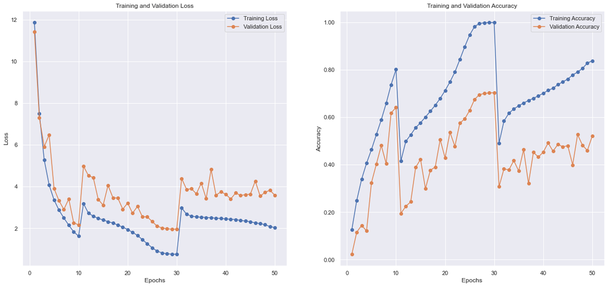

```python
wrn_28_10_results = eval_history.evaluate_model(wrn_28_10,(X_train, y_train), BATCHSIZE,val_ds=(X_val,y_val),
compile_config = COMPILE_CONFIG,wandb_run=wrn_run, epochs=EPOCHS,
additional_cb= [
WandbCallback(monitor="val_categorical_accuracy",save_model=True, save_weights_only=False),
EarlyStopping(monitor='val_categorical_accuracy',
                                patience=20,
                                verbose=1,restore_best_weights=True)],
augmentation=False)
```

# !! SIDE REMARKS !!

- We should see a jaggered pattern. This is normal as we are performing cosine annealing with warm restarts.

```python
display(eval_history.get_history(specific='WRN_28_10').set_index('Model Name'))
display(eval_history.get_history('Baseline'))
```

| Model Name | Model Logs | Epoch | Model Weights/Model | Train Loss | Val Loss | Train Accuracy | Val Accuracy | Training Log Info |
| --- | --- | --- | --- | --- | --- | --- | --- | --- |
| WRN_28_10 | models/WRN_28_10/training.csv | 50 | c:\Users\limhu\Desktop\DELE\CIFAR100\wandb\run... | 0.759531 | 1.963671 | 0.999275 | 0.7033 | c:\Users\limhu\Desktop\DELE\CIFAR100\wandb\run... |

|  | Model Name | Epoch | Model Weights/Model | Train Loss | Val Loss | Train Accuracy | Val Accuracy | Training Log Info |
| --- | --- | --- | --- | --- | --- | --- | --- | --- |
| 0 | Baseline_ConvNN | 20 | c:\Users\limhu\Desktop\DELE\CIFAR100\wandb\run... | 1.337099 | 3.271009 | 0.633175 | 0.3232 | c:\Users\limhu\Desktop\DELE\CIFAR100\wandb\run... |
| 0 | Baseline_DataAug | 50 | C:\Users\limhu\Desktop\DELE\CIFAR100\wandb\run... | 2.267077 | 2.329021 | 0.415900 | 0.4145 | C:\Users\limhu\Desktop\DELE\CIFAR100\wandb\run... |
| 0 | Baseline_L2_Dropout | 45 | c:\Users\limhu\Desktop\DELE\CIFAR100\wandb\run... | 1.855412 | 3.176811 | 0.629325 | 0.3398 | c:\Users\limhu\Desktop\DELE\CIFAR100\wandb\run... |

**WideResNet 28-10 insights**

- The model achieves low avoidable bias, with almost perfect train accuracy, outperforming all the baseline models in terms of both validation and train accuracy.
- We can see that the model still heavily overfits despite having dropout and l2 regularization, given the large deviation between train and validation accuracy as seen from the learning curves
- Hence, we are dealing with an overfitting problem at hand, to further improve the model, i employ the following techniques.

**Changes to further improve the model**

- I have decided to increase early stopping patience to 35 from 20, and further increase the number of epochs to 120. This is to allow the model to run longer to see if the model can improve before getting halted by the early stopping. I decided to make this change as the early stopping had halted the model at around epoch 50, and I wanted to see if the model could improve beyond that epoch.
- Next to reduce overfitting, I will incorporate data augmentation techniques and increased the drop out rate to 0.5

# Data Augmentation

> - Data augmentation is a technique to create new training data from existing training dataset by applying modifications. (expand training set)[Source](https://machinelearningmastery.com/how-to-configure-image-data-augmentation-when-training-deep-learning-neural-networks/)
> - There are different types of image data augmentation categories such as:
>   - Spatial transformation (random-crop, random right/left flip, random rotation, shears, etc)
>   - Color distortion (brightness, hue, etc)
>   - Information dropping (random erasing, grid mask)
> - Data augmentation can act as a regularization tool that can benefit our model by reducing overfitting/lowering variance, by providing the model with more training data. This can help our model to generalize well while having low avoidable bias.
> - One important consideration of why I adopted data augmentation was the fact that it encourages the model to learn general feature maps that are more relevant and robust. Next, CNN has the tendancy to greatly generalize on the training images, hence this results in overfitting the training set, which results in poor generalization, this highlights the need for image augmentation
- It turns out that the model I am trying out later (Wide resnet), image augmentation is important otherwise the network just remembers the train set and generalizes poorly. According to the WideResNet paper [1], Sergey Zagoruyko and Nikos Komodakis performed `horizontal flips and take random crops from image, padded by 4 pixels on each side`, I decided to supplement on to their implementation by including random erasing data augmentation.

### Random cropping & random flipping

1. Random flipping flips the image horizontally, while random cropping(with padding to retain same image size): acts as a form of random translation, by extracting parts of the image
2. I decided to follow the recommendation by Sergey Zagoruyko and Nikos Komodakis[1] of the image augmentation techniques for wide resnets, which is random cropping and horizontal flipping (`horizontal flips and take random crops from image, padded by 4 pixels on each side`). It was also found to work well, demonstrating the ability to supplement each other to produce good accuracy, and are effective data augmentation methods in training of deep CNN [2]. For example, it was the methods used for well known papers of CNN like [Deep Residual Learning for Image Recognition (ResNet)](https://arxiv.org/pdf/1512.03385.pdf). Given all these reasons, I felt it was very appealing to apply these 2 techniques

### Random Erasing

1. To further improve generalization ability, I apply random erasing, to randomly select a rectangle region in an image and erases its pixels and replace with random values, generating images with different levels of occlusion. This reduces overfitting and can improve the robustness towards occlusion & overall performance of the model as well (lower variance).
2. It encourages the model to better use the full context of the image, rather than relying on a small set of specific visual features.
3. I felt it was particularly relevant to integrate random erasing technique for WideResNet. This is due to the following reasons: `1)` Random erasing was found to strongly complement random cropping and random horizontal flipping [2]in which both of them coincidentally worked well for WideResNet [1]. Since random flipping and random cropping work on the image level and are closely related to Random Erasing [2], I felt that it would make sense for all 3 of them to work together in reducing overfitting, further improving the classification performance. `2)` Consistently improving the performance of state-of-the-art model for image classification[2]

```python
def wrn_aug(image):
    image = random_flip_left_right(image)
    image = resize_with_crop_or_pad(image, IMG_SIZE[0] + 4, IMG_SIZE[1] + 4)
    image = random_crop(image, size=IMG_SIZE)
    return image
```

- I decided to follow the [paper's](https://arxiv.org/pdf/1708.04896.pdf) hyperparameters for random erasing.
- There are 4 types of random values for pixels to be replaced with. I decided to go with RE-R, which replaces pixels with random value ranging from [0, 255] or [0,1] for normalized, given that this method are more superior than the rest. [2]

  > Code adapted from: https://github.com/Janghyeonwoong/Random-Erasing-Tensorflow2

[1] [Source](https://arxiv.org/abs/1605.07146) [2] https://arxiv.org/pdf/1708.04896.pdf

> Credits: https://sh-tsang.medium.com/random-erasing-re-random-erasing-data-augmentation-image-classification-37f11627b38

```python
def random_erasing(img, probability = 0.5, sl = 0.02, sh = 0.4, r1 = 0.3):
    '''
    Class that performs Random Erasing in Random Erasing Data Augmentation by Zhong et al.
    -------------------------------------------------------------------------------------
    img : 3D Tensor data (H,W,Channels) normalized value [0,1]
    probability: The probability that the operation will be performed.
    sl: min erasing area
    sh: max erasing area
    r1: min aspect ratio
    method : random erasing type
    -------------------------------------------------------------------------------------
    '''
    if tf.random.uniform([]) > probability:
        return img
    img_width    = img.shape[1]
    img_height   = img.shape[0]
    img_channels = img.shape[2]

    area = img_height * img_width

    target_area = tf.random.uniform([],minval=sl, maxval=sh) * area
    aspect_ratio = tf.random.uniform([],minval=r1, maxval=1/r1)
    h = tf.cast(tf.math.round(tf.math.sqrt(target_area * aspect_ratio)), tf.int32)
    w = tf.cast(tf.math.round(tf.math.sqrt(target_area / aspect_ratio)), tf.int32)

    while tf.constant(True, dtype=tf.bool):
        if h > img_height or w > img_width:
            target_area = tf.random.uniform([],minval=sl, maxval=sh) * area
            aspect_ratio = tf.random.uniform([],minval=r1, maxval=1/r1)
            h = tf.cast(tf.math.round(tf.math.sqrt(target_area * aspect_ratio)), tf.int32)
            w = tf.cast(tf.math.round(tf.math.sqrt(target_area / aspect_ratio)), tf.int32)
        else:
            break

    x1 = tf.cond(img_height == h, lambda:0, lambda:tf.random.uniform([], minval=0, maxval=img_height - h, dtype=tf.int32))
    y1 = tf.cond(img_width  == w, lambda:0, lambda:tf.random.uniform([], minval=0, maxval=img_width - w, dtype=tf.int32))

    part1 = tf.slice(img, [0,0,0], [x1,img_width,img_channels]) # first row
    part2 = tf.slice(img, [x1,0,0], [h,y1,img_channels]) # second row 1


    part3 = tf.random.uniform((h,w,img_channels), dtype=tf.float32)

    part4 = tf.slice(img,[x1,y1+w,0], [h,img_width-y1-w,img_channels]) # second row 3
    part5 = tf.slice(img,[x1+h,0,0], [img_height-x1-h,img_width,img_channels]) # third row

    middle_row = tf.concat([part2,part3,part4], axis=1)
    img = tf.concat([part1,middle_row,part5], axis=0)

    return img

def random_erasing_func(img):
    img = tf.image.convert_image_dtype(img, dtype=tf.float32)
    img = random_erasing(img)
    return img
```

### Data augmentation pipeline

```python
def set_up_data_aug(aug_func = random_erasing_func):
  train_ds = tf.data.Dataset.from_tensor_slices((X_train, y_train)).shuffle(2048)
  val_ds = tf.data.Dataset.from_tensor_slices((X_val, y_val)).shuffle(2048).batch(BATCHSIZE).prefetch(tf.data.AUTOTUNE)
  train_ds = (
    train_ds.shuffle(1024)
    .map(lambda x,y : (wrn_aug(x),y), num_parallel_calls=tf.data.AUTOTUNE)
    .map(lambda x,y :(aug_func(x), y), num_parallel_calls=tf.data.AUTOTUNE)
    .batch(BATCHSIZE)
    .prefetch(tf.data.AUTOTUNE)
)
  return train_ds, val_ds
```

```python
train_aug_ds, val_ds = set_up_data_aug()
```

- We can see that image augmentation was worked as expected.

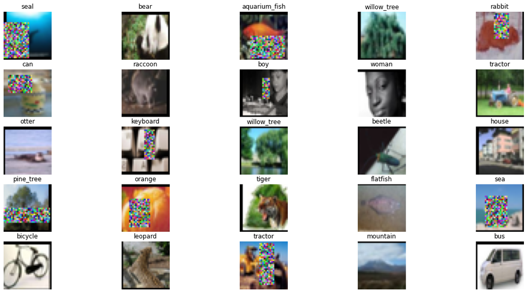

```python
eg_batch, label_batch = next(iter(train_aug_ds))
plt.figure(figsize=(20, 10))
for i in range(25):
    ax = plt.subplot(5, 5, i + 1)
    plt.title(LABELS[np.argmax(label_batch[i])])
    plt.imshow(np.squeeze(eg_batch[i]))
    plt.axis("off")
```

```python
wrn_aug_model = WideResNet(depth=28, k=10, num_classes=100, block=WideResBlock, dropout_rate=0.5)
inp = Input(shape=(32, 32, 3))
wrn_28_10_aug = Model(inputs=[inp], outputs=wrn_aug_model.call(inp), name='WRN_28_10_DataAug')
```

```python
current_time = datetime.datetime.now(pytz.timezone("Singapore")).strftime("%d:%m:%Y_%H:%M")
wrn_data_aug = wandb.init(
    project="CIFAR-100 Image classification",
    name=f"WRN_28_10_WithDataAug{[current_time]}",
    group="WRN_28_10_WithDataAug",
    dir=os.getcwd()
)
```

wandb version 0.13.5 is available! To upgrade, please run: $ pip install wandb --upgrade

Tracking run with wandb version 0.13.4

Run data is saved locally in `c:\Users\limhu\Desktop\DELE\CIFAR100\wandb\run-20221105_132331-adjuvk6s`

Syncing run **[WRN_28_10_WithDataAug['05:11:2022_13:23']](https://wandb.ai/lhurr/CIFAR-100%20Image%20classification/runs/adjuvk6s)** to [Weights & Biases](https://wandb.ai/lhurr/CIFAR-100%20Image%20classification) ([docs](https://wandb.me/run))

```
wandb: WARNING The save_model argument by default saves the model in the HDF5 format that cannot save custom objects like subclassed models and custom layers. This behavior will be deprecated in a future release in favor of the SavedModel format. Meanwhile, the HDF5 model is saved as W&B files and t…
```

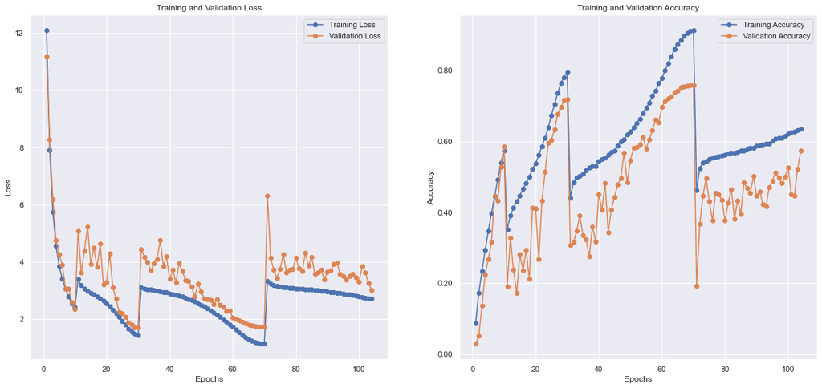

```python
wrn_28_10_data_aug_results = eval_history.evaluate_model(wrn_28_10_aug,train_aug_ds, BATCHSIZE,val_ds=val_ds,
compile_config = COMPILE_CONFIG,wandb_run=wrn_data_aug, epochs=120,
additional_cb= [
WandbCallback(monitor="val_categorical_accuracy",save_model=True, save_weights_only=False),
EarlyStopping(monitor='val_categorical_accuracy',
                                patience=35,
                                verbose=1,restore_best_weights=True)],
augmentation=True)
```

```python
display(eval_history.get_history('WRN_28_10').iloc[[0]])
display(eval_history.get_history('WRN_28_10').iloc[[2]])
```

|  | Model Name | Epoch | Model Weights/Model | Train Loss | Val Loss | Train Accuracy | Val Accuracy | Training Log Info |
| --- | --- | --- | --- | --- | --- | --- | --- | --- |
| 0 | WRN_28_10 | 50 | c:\Users\limhu\Desktop\DELE\CIFAR100\wandb\run... | 0.759531 | 1.963671 | 0.999275 | 0.7033 | c:\Users\limhu\Desktop\DELE\CIFAR100\wandb\run... |

|  | Model Name | Epoch | Model Weights/Model | Train Loss | Val Loss | Train Accuracy | Val Accuracy | Training Log Info |
| --- | --- | --- | --- | --- | --- | --- | --- | --- |
| 0 | WRN_28_10_DataAug | 104 | C:\Users\limhu\Desktop\DELE\CIFAR100\wandb\run... | 1.1457 | 1.7285 | 0.9112 | 0.7583 | C:\Users\limhu\Desktop\DELE\CIFAR100\wandb\run... |

**WRN 28-10-DataAug insights**

1. With simple data augmentation, we have slightly reduced overfitting, as we can see a smaller gap between training and validation accuracy in the learning curves. Our model achieves over 75% validation accuracy.
2. However, the model still overfits greatly.

# Competitive Inner-Imaging Squeeze and Excitation (CMPESE) blocks

- [Squeeze and excitation blocks](https://arxiv.org/pdf/1709.01507.pdf) can be integrated into networks like wide resnets, vgg net. The main idea behind SE blocks is to add parameters to each channel of a convolutional block that allow the network adjust the weighting of each feature map. Since the network weights each of its channels equally when creating the output feature maps. [SENets are all about changing this by adding a content aware mechanism to weight each channel adaptively.](https://towardsdatascience.com/squeeze-and-excitation-networks-9ef5e71eacd7). This can be seen as a form of Channel Wise attention for the model

# Squeeze operation

- The main purpose of the Squeeze operation is to extract global information from each of the channels of an image. Since, convolution is a local operation, it might be beneficial to also extract information outside the receptive field of the convolution filter. This is done via global average pooling

# Excitation operation

- To generate a set of weights for each channel. Excitation operation is used.

# CMPESE

- However, the problem with Squeeze and excitation blocks is that, only the residual information is only used to determine the weight of each feature-map, reducing the impact of SEBlock.
- [Hu et al.](https://arxiv.org/pdf/1807.08920.pdf) designed the Competitive Inner-Imaging Squeeze and Excitation architecture based on the SE block in 2018 to improve the learning of deep residual networks. Their aim was to expand the factors considered in the channel re-weighting of residual mappings and use their design to model implicit competitive relationship between identity and residual feature maps)
- Hu et al. tackled the issue by introducing identity flow into the process of squeeze excitation. Hence, the creation of feature-map was from both residual and identity mapping feature-maps.
- For this, I wentwith CMPE-SE block of the version with double fully connected embedding for squeezed signals, which are merged in the excitation layer.

Source: https://arxiv.org/pdf/1807.08920.pdf

[figure not shown]

- Code adapted from github, however it was in MXnet implementation so i had to modify and change to tensorflow https://github.com/scut-aitcm/Competitive-Inner-Imaging-SENet

```python
NET_SE_RATIO = 16
class CMPESEBlockDoubleFC(Model):
    def __init__(self, out_channels, block_grp, block_num, WEIGHT_DECAY = WEIGHT_DECAY):
        super(CMPESEBlockDoubleFC, self).__init__()

        if block_grp == 1:
            stride = 1
            self.conv_sc = Conv2D(out_channels, kernel_size=1, strides=stride, padding='same', use_bias=False, kernel_regularizer=l2(WEIGHT_DECAY), kernel_initializer='he_normal')
            self.bn_sc = BatchNormalization(epsilon=1e-5, gamma_initializer='uniform')
        elif block_num == 0:
            stride = 2
            self.conv_sc = Conv2D(out_channels, kernel_size=1, strides=stride, padding='same', use_bias=False, kernel_regularizer=l2(WEIGHT_DECAY), kernel_initializer='he_normal')
            self.bn_sc = BatchNormalization(epsilon=1e-5, gamma_initializer='uniform')
        else:
            stride = 1
            self.conv_sc = None

        self.activation = Activation('relu')
        self.bn1 = BatchNormalization(epsilon=1e-5, gamma_initializer='uniform')
        self.dropout = Dropout(rate=0.3)

        self.conv1 = Conv2D(out_channels, kernel_size=3, strides=stride, padding='same',use_bias=False, kernel_regularizer=l2(WEIGHT_DECAY), kernel_initializer='he_normal')
        self.bn2 = BatchNormalization()
        self.conv2 = Conv2D(out_channels, kernel_size=3, strides=1, padding='same', use_bias=False, kernel_regularizer=l2(WEIGHT_DECAY), kernel_initializer='he_normal')

        self.net_se_input_glob  =  GlobalAveragePooling2D(keepdims =True)
        self.net_se_input_conv =  Conv2D(out_channels // NET_SE_RATIO,strides=stride, kernel_size=1, use_bias=False, padding='same',kernel_regularizer=l2(WEIGHT_DECAY), kernel_initializer='he_normal')
        self.activation1 = Activation('relu')
        self.net_se_input_x_glob =  GlobalAveragePooling2D(keepdims=True)
        self.net_se_input_x_conv =   Conv2D(out_channels // NET_SE_RATIO,strides =stride, kernel_size=1, use_bias=False, padding='same', kernel_regularizer=l2(WEIGHT_DECAY), kernel_initializer='he_normal')

        self.activation2 = Activation('relu')
        self.net_se_conv = Conv2D(out_channels, kernel_size=1,strides=stride, use_bias=False, padding = 'same', kernel_regularizer=l2(WEIGHT_DECAY), kernel_initializer='he_normal')
        self.net_se_act = Activation(activation='sigmoid')

    def call(self, x):
        shortcut = x
        x = self.bn1(x)
        x = self.activation(x)
        if self.conv_sc is not None:
            shortcut = self.conv_sc(x)

        conv_out = self.conv1(x)
        conv_out = self.bn2(conv_out)
        conv_out = self.activation(conv_out)
        conv_out = self.conv2(conv_out)

        se_input_conv = self.net_se_input_glob(conv_out)
        se_input_conv = self.net_se_input_conv(se_input_conv)
        se_input_conv = self.activation1(se_input_conv)

        se_input_skipx = self.net_se_input_x_glob(shortcut)
        se_input_skipx = self.net_se_input_x_conv(se_input_skipx)
        se_input_skipx = self.activation2(se_input_skipx)

        se_input = concatenate([se_input_conv, se_input_skipx], axis=-1)

        se_out = self.net_se_conv(se_input)
        se_out = self.net_se_act(se_out)

        return conv_out * se_out + shortcut
```

```python
train_augcmpese_ds, val_cmpese_ds =set_up_data_aug()
```

```python
wrn_model = WideResNet(depth=28, k=10, num_classes=100, block=CMPESEBlockDoubleFC)
inp = Input(shape=(32, 32, 3))
wrn_28_10_aug = Model(inputs=[inp], outputs=wrn_model.call(inp), name='WRN_28_10_RandomErasing_CMPESE')
```

```python
wrn_28_10_aug.summary()
```

```
Model: "WRN_28_10_RandomErasing_CMPESE"
_________________________________________________________________
 Layer (type)                Output Shape              Param #
=================================================================
 input_5 (InputLayer)        [(None, 32, 32, 3)]       0

 conv2d_232 (Conv2D)         (None, 30, 30, 16)        432

 cmpese_block_double_fc_36 (  (None, 30, 30, 160)      263104
 CMPESEBlockDoubleFC)

 cmpese_block_double_fc_37 (  (None, 30, 30, 160)      494080
 CMPESEBlockDoubleFC)

 cmpese_block_double_fc_38 (  (None, 30, 30, 160)      494080
 CMPESEBlockDoubleFC)

 cmpese_block_double_fc_39 (  (None, 30, 30, 160)      494080
 CMPESEBlockDoubleFC)

 cmpese_block_double_fc_40 (  (None, 15, 15, 320)      1461120
 CMPESEBlockDoubleFC)

 cmpese_block_double_fc_41 (  (None, 15, 15, 320)      1871360
 CMPESEBlockDoubleFC)

 cmpese_block_double_fc_42 (  (None, 15, 15, 320)      1871360
 CMPESEBlockDoubleFC)

 cmpese_block_double_fc_43 (  (None, 15, 15, 320)      1871360
 CMPESEBlockDoubleFC)

 cmpese_block_double_fc_44 (  (None, 8, 8, 640)        5840640
 CMPESEBlockDoubleFC)

 cmpese_block_double_fc_45 (  (None, 8, 8, 640)        7480320
 CMPESEBlockDoubleFC)

 cmpese_block_double_fc_46 (  (None, 8, 8, 640)        7480320
 CMPESEBlockDoubleFC)

 cmpese_block_double_fc_47 (  (None, 8, 8, 640)        7480320
 CMPESEBlockDoubleFC)

 bn_input (BatchNormalizatio  (None, 8, 8, 640)        2560
 n)

 activation_208 (Activation)  (None, 8, 8, 640)        0

 pool_output (GlobalAverageP  (None, 640)              0
 ooling2D)

 output (Dense)              (None, 100)               64100

=================================================================
Total params: 37,169,236
Trainable params: 37,151,284
Non-trainable params: 17,952
_________________________________________________________________
```

- We noticed a small parameter increase in the model

```python
current_time = datetime.datetime.now(pytz.timezone("Singapore")).strftime("%d:%m:%Y_%H:%M")
wrn_data_aug_cmpese = wandb.init(
    project="CIFAR-100 Image classification",
    name=f"WRN_28_10_RandomErasing_CMPSE{[current_time]}",
    group="WRN_28_10_RandomErasing_CMPSE",
    dir=os.getcwd()
)
```

```
wandb: WARNING The save_model argument by default saves the model in the HDF5 format that cannot save custom objects like subclassed models and custom layers. This behavior will be deprecated in a future release in favor of the SavedModel format. Meanwhile, the HDF5 model is saved as W&B files and t…
```

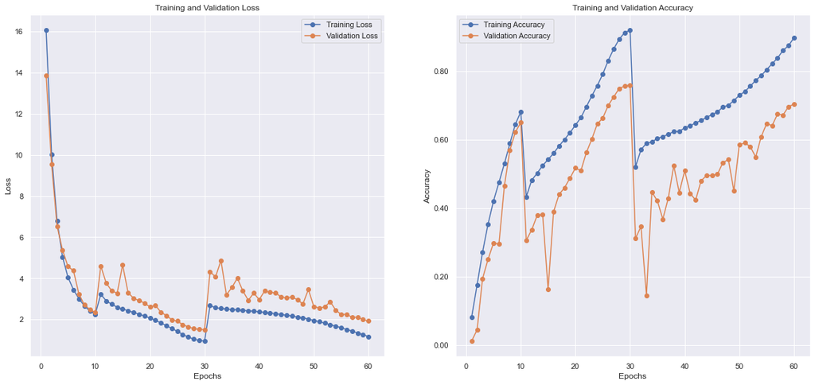

```python
wrn_28_10_data_aug_cmpse_results = eval_history.evaluate_model(wrn_28_10_aug,train_augcmpese_ds, BATCHSIZE,val_ds=val_cmpese_ds,
compile_config = COMPILE_CONFIG,wandb_run=wrn_data_aug_cmpese, epochs=EPOCHS,
additional_cb= [
WandbCallback(monitor="val_categorical_accuracy",save_model=True, save_weights_only=False),
EarlyStopping(monitor='val_categorical_accuracy',
                                patience=40,
                                verbose=1,restore_best_weights=True)
],augmentation=True)
```

```python
display(eval_history.get_history('WRN_28_10_RandomErasing'))
```

[output not shown]

**WRN 28-10 w basic augmentation & competitive competitive inner imaging squeeze and excitation blocks insights**

- By including competitive inner imaging squeeze and excitation blocks on top of random flipping/cropping and erasing, we notice that the distinct improvement in our model.
- We are able to achieve the same accuracy scores as the normal wide resnet BUT in half the number of epochs the original WRN took. The Improved WRN took 30 epochs to reach 76% validation accuracy, while original WRN took 75 epochs to achieve 75% validation accuracy. Effectively, we have reduced the training time as well. This is very good for us as we know that the model is more robust and is able to converge better.
- After making architectural improvements, we still have a very clear problem we need to deal with which is overfitting. Even despite basic augmentation our wide residual nets are greatly overfitting. We need to increase the strength of the augmentation technique by introducing a stronger technique.

# Stronger data augmentation techniques (CUTMIX)

- To improve the performance of the model, we will employ a stronger augmentation technique called cutmix to further reduce overfitting, introduced in [Regularization Strategy to Train Strong Classifiers with Localizable Features](https://arxiv.org/pdf/1905.04899v2.pdf). (Yun et al., 2019)
- Cutmix replaces a patch of an image with a patch of another image from training set. The labels are also mixed proportionally to the number of pixels of combined images.
- In a way, cutmix minimizes information loss & increases localization ability by making the model to focus on less discriminative parts of the object being classified.

```python
def sample_beta_distribution(size, concentration_0=0.2, concentration_1=0.2):
  gamma_1_sample = tf.random.gamma(shape=[size], alpha=concentration_1)
  gamma_2_sample = tf.random.gamma(shape=[size], alpha=concentration_0)
  return gamma_1_sample / (gamma_1_sample + gamma_2_sample)


@tf.function
def get_box(lambda_value):
  cut_rat = tf.math.sqrt(1.0 - lambda_value)
  image_wh = IMG_SIZE[0]
  cut_wh = image_wh * cut_rat  # rw
  cut_wh = tf.cast(cut_wh, tf.int32)

  cut_x = tf.random.uniform((1,), minval=0, maxval=image_wh, dtype=tf.int32)  # rx
  cut_y = tf.random.uniform((1,), minval=0, maxval=image_wh, dtype=tf.int32)  # ry

  boundaryx1 = tf.clip_by_value(cut_x[0] - cut_wh // 2, 0, image_wh)
  boundaryy1 = tf.clip_by_value(cut_y[0] - cut_wh // 2, 0, image_wh)
  bbx2 = tf.clip_by_value(cut_x[0] + cut_wh // 2, 0, image_wh)
  bby2 = tf.clip_by_value(cut_y[0] + cut_wh // 2, 0, image_wh)

  target_h = bby2 - boundaryy1
  if target_h == 0:
      target_h += 1

  target_w = bbx2 - boundaryx1
  if target_w == 0:
      target_w += 1

  return boundaryx1, boundaryy1, target_h, target_w


@tf.function
def cutmix(train_ds_one, train_ds_two):
  (image1, label1), (image2, label2) = train_ds_one, train_ds_two
  image_size = IMG_SIZE[0]
  alpha = [1]
  beta = [1]

  # Get a sample from the Beta distribution
  lambda_value = sample_beta_distribution(1, alpha, beta)

  # Define Lambda
  lambda_value = lambda_value[0][0]

  # Get the bounding box offsets, heights and widths
  boundaryx1, boundaryy1, target_h, target_w = get_box(lambda_value)

  # Get a patch from the second image (`image2`)
  crop2 = tf.image.crop_to_bounding_box(
      image2, boundaryy1, boundaryx1, target_h, target_w
  )
  # Pad the `image2` patch (`crop2`) with the same offset
  image2 = tf.image.pad_to_bounding_box(
      crop2, boundaryy1, boundaryx1, image_size, image_size
  )
  # Get a patch from the first image (`image1`)
  crop1 = tf.image.crop_to_bounding_box(
      image1, boundaryy1, boundaryx1, target_h, target_w
  )
  # Pad the `image1` patch (`crop1`) with the same offset
  img1 = tf.image.pad_to_bounding_box(
      crop1, boundaryy1, boundaryx1, image_size, image_size
  )

  # Modify the first image by subtracting the patch from `image1`
  # (before applying the `image2` patch)
  image1 = image1 - img1
  # Add the modified `image1` and `image2`  together to get the CutMix image
  image = image1 + image2

  # Adjust Lambda in accordance to the pixel ration
  lambda_value = 1 - (target_w * target_h) / (image_size * image_size)
  lambda_value = tf.cast(lambda_value, tf.float32)

  # Combine the labels of both images
  label = lambda_value * label1 + (1 - lambda_value) * label2
  return image, label
```

```python
def set_up_cut_mix(X_train, y_train):
    AUTO = tf.data.AUTOTUNE
    train_ds_one = (
        tf.data.Dataset.from_tensor_slices((X_train, y_train))
        .shuffle(2048)
    )
    train_ds_two = (
        tf.data.Dataset.from_tensor_slices((X_train, y_train))
        .shuffle(2048)
    )
    train_ds = tf.data.Dataset.zip((train_ds_one, train_ds_two))

    train_ds = (train_ds.shuffle(1024).map(cutmix, num_parallel_calls=AUTO)
    .batch(BATCHSIZE)
    .prefetch(AUTO)
    )

    val_ds = tf.data.Dataset.from_tensor_slices((X_val, y_val)).shuffle(2048).batch(BATCHSIZE).prefetch(tf.data.AUTOTUNE)
    return train_ds,val_ds

train_cm_ds, val_ds =set_up_cut_mix(X_train,y_train)
```

**Sample cutmix images**

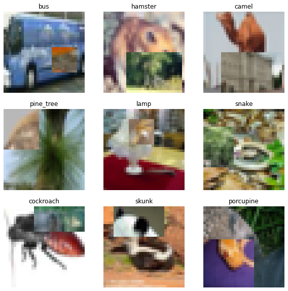

```python
image_batch, label_batch = next(iter(train_cm_ds))
plt.figure(figsize=(10, 10))
for i in range(9):
    ax = plt.subplot(3, 3, i + 1)
    plt.title(LABELS[np.argmax(label_batch[i])])
    plt.imshow(tf.squeeze(image_batch[i]))
    plt.axis("off")
```

```python
wrn_mixup_cmpese = WideResNet(depth=28, k=10, num_classes=100, block=CMPESEBlockDoubleFC)
inp = Input(shape=(32, 32, 3))
wrn_28_10_cmpese_cutmix = Model(inputs=[inp], outputs=wrn_mixup_cmpese.call(inp), name='WRN_28_10_CutMix_CMPESE')
```

```python
current_time = datetime.datetime.now(pytz.timezone("Singapore")).strftime("%d:%m:%Y_%H:%M")
wrn_cmix_cmpese = wandb.init(
    project="CIFAR-100 Image classification",
    name=f"WRN_28_10_CutMix_CMPESE{[current_time]}",
    group="WRN_28_10_CutMix_CMPESE",
    dir=os.getcwd()
)
```

```
wandb: WARNING The save_model argument by default saves the model in the HDF5 format that cannot save custom objects like subclassed models and custom layers. This behavior will be deprecated in a future release in favor of the SavedModel format. Meanwhile, the HDF5 model is saved as W&B files and t…
```

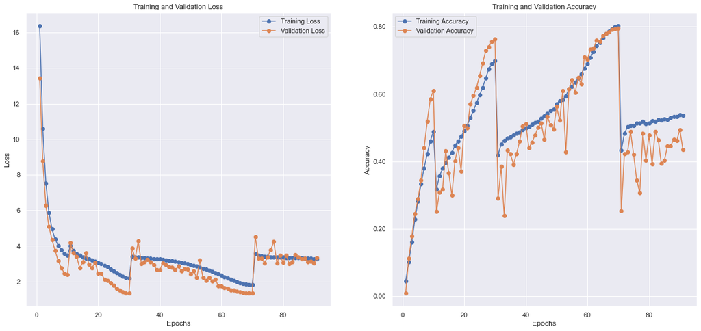

```python
wrn_28_10_mixup_cmpse_results = eval_history.evaluate_model(wrn_28_10_cmpese_cutmix,train_cm_ds, BATCHSIZE,val_ds=val_ds,
compile_config = COMPILE_CONFIG,wandb_run=wrn_cmix_cmpese, epochs=120,
additional_cb=
[WandbCallback(monitor="val_categorical_accuracy",save_model=True, save_weights_only=False),
EarlyStopping(monitor='val_categorical_accuracy',
                                patience=40,
                                verbose=1,restore_best_weights=True)
]
,
augmentation=True)
```

```python
display(eval_history.get_history('WRN_28_10_'))
```

|  | Model Name | Epoch | Model Weights/Model | Train Loss | Val Loss | Train Accuracy | Val Accuracy | Training Log Info |
| --- | --- | --- | --- | --- | --- | --- | --- | --- |
| 0 | WRN_28_10_CutMix_CMPESE | 91 | C:\Users\limhu\Desktop\DELE\CIFAR100\wandb\run... | 1.8186 | 1.3480 | 0.8017 | 0.7944 | C:\Users\limhu\Desktop\DELE\CIFAR100\wandb\run... |
| 0 | WRN_28_10_DataAug | 104 | C:\Users\limhu\Desktop\DELE\CIFAR100\wandb\run... | 1.1457 | 1.7285 | 0.9112 | 0.7583 | C:\Users\limhu\Desktop\DELE\CIFAR100\wandb\run... |
| 0 | WRN_28_10_RandomErasing_CMPESE | 50 | C:\Users\limhu\Desktop\DELE\CIFAR100\wandb\run... | 0.9539 | 1.5098 | 0.9189 | 0.7586 | C:\Users\limhu\Desktop\DELE\CIFAR100\wandb\run... |

# **Model Evaluation**

```python
display(eval_history.get_history(''))
```

|  | Model Name | Epoch | Model Weights/Model | Train Loss | Val Loss | Train Accuracy | Val Accuracy | Training Log Info |
| --- | --- | --- | --- | --- | --- | --- | --- | --- |
| 0 | Baseline_ConvNN | 20 | c:\Users\limhu\Desktop\DELE\CIFAR100\wandb\run... | 1.337099 | 3.271009 | 0.633175 | 0.3232 | c:\Users\limhu\Desktop\DELE\CIFAR100\wandb\run... |
| 0 | Baseline_DataAug | 50 | C:\Users\limhu\Desktop\DELE\CIFAR100\wandb\run... | 2.267077 | 2.329021 | 0.415900 | 0.4145 | C:\Users\limhu\Desktop\DELE\CIFAR100\wandb\run... |
| 0 | Baseline_L2_Dropout | 45 | c:\Users\limhu\Desktop\DELE\CIFAR100\wandb\run... | 1.855412 | 3.176811 | 0.629325 | 0.3398 | c:\Users\limhu\Desktop\DELE\CIFAR100\wandb\run... |
| 0 | BottleNeck-PyramidNet220-236-ShakeDrop-Cutmix | 100 | C:\Users\limhu\Desktop\DELE\CIFAR100\wandb\run... | 2.072900 | 1.196700 | 0.715900 | 0.7511 | C:\Users\limhu\Desktop\DELE\CIFAR100\wandb\run... |
| 0 | BottleNeck_PyramidNet | 55 | C:\Users\limhu\Desktop\DELE\CIFAR100\wandb\run... | 0.251900 | 1.737000 | 0.999700 | 0.6539 | C:\Users\limhu\Desktop\DELE\CIFAR100\wandb\run... |
| 0 | BottleNeck_PyramidNet_84_164_ShakeDrop_Cutmix | 78 | C:\Users\limhu\Desktop\DELE\CIFAR100\wandb\run... | 2.400000 | 1.374000 | 0.658300 | 0.7264 | C:\Users\limhu\Desktop\DELE\CIFAR100\wandb\run... |
| 0 | WRN_28_10 | 50 | c:\Users\limhu\Desktop\DELE\CIFAR100\wandb\run... | 0.759531 | 1.963671 | 0.999275 | 0.7033 | c:\Users\limhu\Desktop\DELE\CIFAR100\wandb\run... |
| 0 | WRN_28_10_CutMix_CMPESE | 91 | C:\Users\limhu\Desktop\DELE\CIFAR100\wandb\run... | 1.818600 | 1.348000 | 0.801700 | 0.7944 | C:\Users\limhu\Desktop\DELE\CIFAR100\wandb\run... |
| 0 | WRN_28_10_DataAug | 104 | C:\Users\limhu\Desktop\DELE\CIFAR100\wandb\run... | 1.145700 | 1.728500 | 0.911200 | 0.7583 | C:\Users\limhu\Desktop\DELE\CIFAR100\wandb\run... |
| 0 | WRN_28_10_RandomErasing_CMPESE | 50 | C:\Users\limhu\Desktop\DELE\CIFAR100\wandb\run... | 0.953900 | 1.509800 | 0.918900 | 0.7586 | C:\Users\limhu\Desktop\DELE\CIFAR100\wandb\run... |

# !! Final Model !!

- Wide Residual Net with 28 depth and widening factor of 10
- Pre activation structure
- Increased dropout rates between conv layers (prevent overfitting)
- L2 regularization
- Competitive squeeze and excitation blocks
- Cutmix data augmentation
- SGD with nesterov momentum with cosine annealing with warm restarts LR scheduler.

## Hyperparameter tuning

1. I noticed that our final model still overfits by around 0.5% ish. Hence, as my final resort to reduce the training and validation gap, I will perform hyperparameter tuning.
2. We will try and select the most optimal batch size and l2 regularization rate.
3. As of now, our batch size is 128 and l2 regularization/weight decay is 0.0005. To try and reduce the gap, I try and increase the weight decay by tuning the weight decay value from a range of 0.0006 to 0.001 to see if any more improvement can be made to the model. I did not go below this range as any lower would result in the model overfitting further. Increasing further may result in our model underfitting, which is not ideal.
4. I also tune the batch size value as well from a range of values: [64,128,256]. I want to see if increasing the batch size would allow for a more stable accuracy increase. Similarly, i also tried a batch size of 64 to see if we can introduce more noise into gradient updates for a regularization effect

```python
import keras_tuner as kt
from keras_tuner import BayesianOptimization
```

```python
class WideResNet(Model):
    def __init__(self, depth, k, num_classes, block:CMPESEBlockDoubleFC = CMPESEBlockDoubleFC, wd = 0.0005):
        super().__init__()
        self._layers = []
        N = (depth - 4) // 6
        self._layers += [
            Conv2D(filters = 16, kernel_size = 3, kernel_regularizer=l2(WEIGHT_DECAY), use_bias=False, kernel_initializer='he_normal')
        ]
        # Residual block group (thats why have 3 lists)
        self._layers += [block(out_channels=16*k, block_grp=1, block_num=i, WEIGHT_DECAY= wd ) for i in range(N)]
        self._layers += [block(out_channels=32*k, block_grp=2, block_num=i, WEIGHT_DECAY= wd) for i in range(N)]
        self._layers += [block(out_channels=64*k, block_grp=3, block_num=i, WEIGHT_DECAY= wd) for i in range(N)]

        self._layers += [
            BatchNormalization(name='bn_input'),
            Activation('relu'),
            GlobalAveragePooling2D(name='pool_output'),
            Dense(num_classes, activation='softmax', name='output', kernel_regularizer=l2(WEIGHT_DECAY), kernel_initializer='he_normal')
        ]

    def call(self, x):
        for layer in self._layers:
            x = layer(x)
        return x
```

```python
def set_up_cut_mix(X_train, y_train):
    AUTO = tf.data.AUTOTUNE
    train_ds_one = (
        tf.data.Dataset.from_tensor_slices((X_train, y_train))
        .shuffle(2048)
    )
    train_ds_two = (
        tf.data.Dataset.from_tensor_slices((X_train, y_train))
        .shuffle(2048)
    )
    train_ds = tf.data.Dataset.zip((train_ds_one, train_ds_two))

    train_ds = (train_ds.shuffle(1024).map(cutmix, num_parallel_calls=AUTO)
    # .batch(BATCHSIZE)
    .prefetch(AUTO)
    )

    val_ds = tf.data.Dataset.from_tensor_slices((X_val, y_val)).shuffle(2048).prefetch(tf.data.AUTOTUNE)
    return train_ds,val_ds

train_cm_ds, val_ds =set_up_cut_mix(X_train,y_train)
```

```python
class CustomHyperModel(kt.HyperModel):
    def build(self, hp):
        wd = hp.Choice("weight_decay", [0.0006,  0.0007, 0.0008,  0.0009, 0.001])
        wrn_tune = WideResNet(depth=28, k=10, num_classes=100, block=CMPESEBlockDoubleFC, wd = wd)
        inp = Input(shape=(32, 32, 3))
        wrn_final = Model(inputs=[inp], outputs=wrn_tune.call(inp), name='WRN_28_10_CutMix_BasicAug_CMPESE_Tuned')
        wrn_final.compile(**COMPILE_CONFIG)
        return wrn_final
    def fit(self, hp, model ,*args, **kwargs):
        dataset = args[0]
        val_ds = args[1]
        batch = hp.Choice("batch_size", [64,128, 256])

        return model.fit(
            dataset.batch(batch),
            validation_data = val_ds.batch(batch),
            **kwargs,
        )

tuner = kt.RandomSearch(
    CustomHyperModel(),
    objective="val_categorical_accuracy",
    max_trials=3,
    overwrite=True,
    project_name="WRN_CF100",
)
tuner.search(train_cm_ds, val_ds, epochs=75,callbacks=[
EarlyStopping(monitor="val_accuracy", patience=15, restore_best_weights=True), annealing
]
)
tuner.results_summary(num_trials=2)
```

```
Trial 3 Complete [00h 54m 56s]
val_categorical_accuracy: 0.717199981212616
Best val_categorical_accuracy So Far: 0.787199981212616
Total elapsed time: 02h 46m 46s
Results summary
Results in ./WRN_CF100
Showing 2 best trials
<keras_tuner.engine.objective.Objective object at 0x7f6eed8a3190>
Trial summary
Hyperparameters:
weight_decay: 0.0008
batch_size: 64
Score: 0.787199981212616
Trial summary
Hyperparameters:
weight_decay: 0.0009
batch_size: 256
Score: 0.717199981212616
```

- After running on colab , we have managed to tune the model, but however, we do not see an effective increase in validation accuracy. We note that batch size of 256 does not improve the model at all, hence we have to stick with 128. Tuning the l2 regularization parameter also did not have significant improvement. However, now we are more confident that our batch size and l2 regularization parameter are more robust.
- Due to very expensive time costs to run (10+ hours for normal GPU), we are forced to halt hyperparameter tuning at 3 trials due to its large computational costs.

## Model evaluation for cifar100 FINE labels

```python
eval_history.get_history('WRN_28_10_CutMix_CMPESE')
```

|  | Model Name | Epoch | Model Weights/Model | Train Loss | Val Loss | Train Accuracy | Val Accuracy | Training Log Info |
| --- | --- | --- | --- | --- | --- | --- | --- | --- |
| 0 | WRN_28_10_CutMix_CMPESE | 91 | C:\Users\limhu\Desktop\DELE\CIFAR100\wandb\run... | 1.8186 | 1.348 | 0.8017 | 0.7944 | C:\Users\limhu\Desktop\DELE\CIFAR100\wandb\run... |

We will now evaluate the final model. To make sure our final model is robust and that it generalizes well, we want to make sure that the accuracy on test set is similar to the validation accuracy or is somewhere between the train and validation accuracy.

```python
final_model = load_model('wandb\run-20221105_215701-3maa813d\files\artifacts')
final_model.evaluate(X_test,y_test)
```

```
[1.3467553853988647, 0.7968999743461609]
```

- Our model performs very well on the independant hold out test set, obtaining 79.7% accuracy, which is pretty decent. Furthermore, we can see that the the score is very close to the validation accuracy, while sitting between the range of training and validation accuracy. This suggests that the model does not overfit, thus possesing low variance. Given that this is the first time the model came across this set and performed well, it suggests that our model is able to generalize well to new examples.

# Final model evaluation:

### Classification report and confusion matrix

|  | precision | recall | f1-score | support |
| --- | --- | --- | --- | --- |
| girl | 0.520408 | 0.51 | 0.515152 | 100.0 |
| boy | 0.525424 | 0.62 | 0.568807 | 100.0 |
| lizard | 0.563107 | 0.58 | 0.571429 | 100.0 |
| seal | 0.585859 | 0.58 | 0.582915 | 100.0 |
| man | 0.635294 | 0.54 | 0.583784 | 100.0 |
| ... | ... | ... | ... | ... |
| sunflower | 0.948980 | 0.93 | 0.939394 | 100.0 |
| wardrobe | 0.940000 | 0.94 | 0.940000 | 100.0 |
| orange | 0.931373 | 0.95 | 0.940594 | 100.0 |
| aquarium_fish | 0.958763 | 0.93 | 0.944162 | 100.0 |
| apple | 0.932039 | 0.96 | 0.945813 | 100.0 |

103 rows × 4 columns

```
'Test accuracy score:'
```

```
0.7969
```

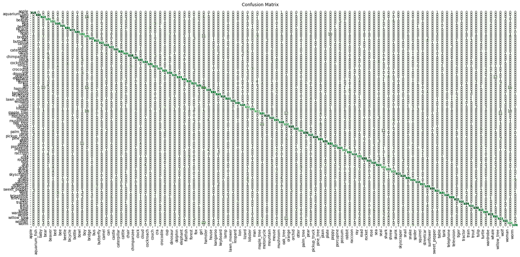

```python
fig = plt.figure(figsize=(20, 10))
y_pred = final_model.predict(X_test)
cm = confusion_matrix(y_test.argmax(axis=1),y_pred.argmax(axis=1))
sns.heatmap(cm, annot=True, fmt='g', cbar=False, cmap='Greens')

fig.suptitle(f'Confusion Matrix')
plt.xticks(range(0,100),[x for x in LABELS.values()])
plt.yticks(range(0,100),[y for y in LABELS.values()])

display(pd.DataFrame(classification_report(y_test.argmax(axis=1), y_pred.argmax(axis=1), target_names=LABELS.values(), output_dict=True)).T.sort_values('f1-score'))
display('Test accuracy score:',accuracy_score(np.argmax(y_test, axis=1), np.argmax(y_pred,axis=1)))
plt.tight_layout()
```

1. From the classification report, we can see that the model has a hard time classifying living things, such as `girl`, `boy`, as denoted by the lower recall and precision scores.
2. The model however is able to more accurately classify objects with a standard silhouette like oranges, apples and nature plants like sunflower. We can see that for these classes, the recall and precision score is high.

# Error analysis

1. We perform analysis to analyze where the model went wrong in terms of predictions.

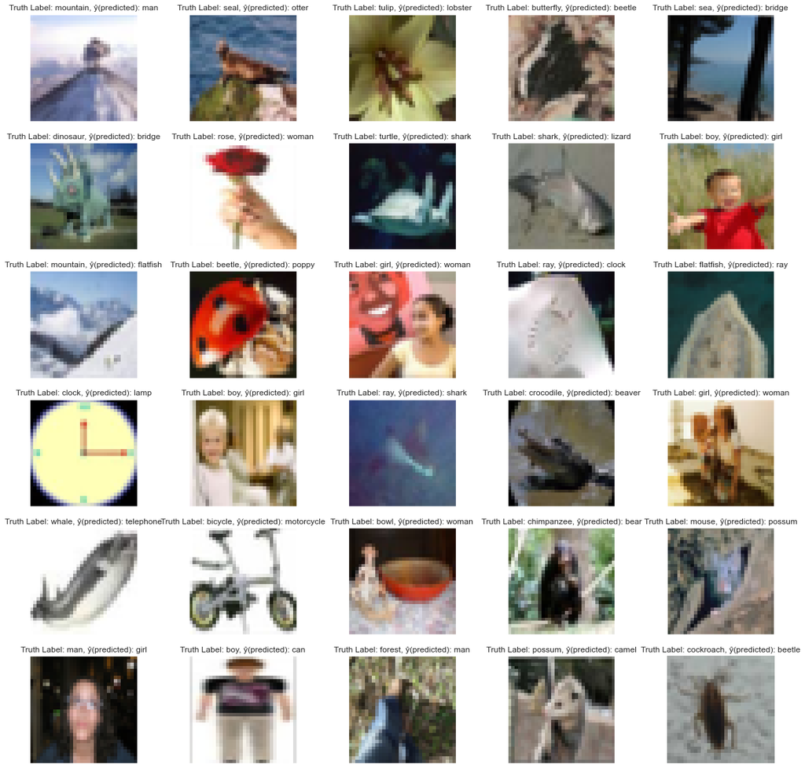

```python
y_pred_labels = np.argmax(y_pred, axis=1)
wrong_example_mask = (np.argmax(y_test, axis=1) != y_pred_labels)
X_test_wrong = X_test[wrong_example_mask]
y_test_wrong = np.argmax(y_test[wrong_example_mask], axis=1)
y_pred_wrong = y_pred_labels[wrong_example_mask]

fig, ax = plt.subplots(6, 5, figsize=(20, 20))
fig.patch.set_facecolor('white')
plt.axis("off")
for idx, axz in zip(np.arange(0,30,1), ax.ravel()):
  axz.imshow(X_test_wrong[idx])
  axz.grid(False)
  axz.set_xticks([])
  axz.set_yticks([])

  axz.set_title(f"Truth Label: {LABELS[y_test_wrong[idx]]}, ŷ(predicted): {LABELS[y_pred_wrong[idx]]}")
```

- We notice a similar trend among wrong predictions: The images are of very low resolution, where the model, let alone a human can get confused easily. For example, for the animal images above, it is very hard to deduce what it is exactly. In addition, some animals do have the same shape and silhouette, which can be confusing to classify as well. This could explain why the model do not do well for mammals/animals like seal.
- The classification report also showed that the model is poor in classifying humans in general, more specifically: girl and boy. As we scrutinize the errors the model made for these 2 classes above, I believe that humans would also have difficulty classifying between the 2 as well, given the low resolution and that it can be quite subjective to decide the gender through just an image.
- Given this, I believe that these errors could also be made by humans, hence it is very valid for our model to classify them wrongly, in addition reasons stated above.

# TSNE plot for error analysis

- We will plot a tsne plot for further error analysis

```python
from sklearn.manifold import TSNE
```

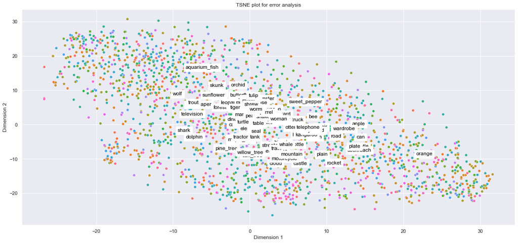

```python
def tsne_2d(X_predwrong,y_predwrong):
  sns.set()
  plt.figure(figsize=(20,9))
  x_reshaped = pd.DataFrame(np.reshape(X_predwrong, (X_predwrong.shape[0], 32*32*3)))

  tsne_inst = TSNE(n_components=2, random_state=42)
  tsne_results = tsne_inst.fit_transform(x_reshaped)

  reduced_2d = pd.DataFrame(tsne_results, columns=('Dimension 1', 'Dimension 2'))
  reduced_2d['label'] = [LABELS[i] for i in y_predwrong.astype('int')]

  center = reduced_2d.groupby('label')[['Dimension 1', 'Dimension 2']].mean()

  sns.scatterplot(data=reduced_2d, x='Dimension 1', y='Dimension 2', hue='label')

  for i in range(len(LABELS)):
    plt.text(center.iloc[i,0], center.iloc[i,1], f'{center.index[i]}', size='medium', color='black', bbox=dict(facecolor='white', alpha=1.0))
  plt.title('TSNE plot for error analysis')
  plt.legend().set_visible(False)
  return reduced_2d, center
reduced, ctr = tsne_2d(X_test_wrong, y_test_wrong)
```

- From the TSNE plot, we are able to see that the wrongly classified image classes are overlapping with each other.

# Summary & reflection

1. We have managed to experiment with state of the art model architectures and training techniques to achieve a good accuracy score for the CIFAR-100 fine labels task. A model with high bias is limited from learning the true trend, hence underfitting, while high variance overfits the training data. Overall, we managed to overcome the bias variance trade-off, and our model now posses decently low bias and variance.
2. Moreover, along with extensive image augmentation and architectural improvement attempts, we managed to obtain a relatively good score. Also, through research about training techniques and architectures, i have also managed to gain more knowledge in the field of CNNs.
3. In the future, I wish to explore more on convolutional neural networks, particularly model architectures and image augmentation techniques to enhance my understanding in deep learning

```python
!jupyter nbconvert --to html 3_WideResNet.ipynb
```